# Hypothesis Testing

Institut für Organisation und Globale Managementstudien, JKU Linz

## Hypothesis testing

- Hypothesis testing is concerned with **making decisions** using data
- A null hypothesis is specified that represents the **status quo**,  
  usually labeled **\(H_0\)**
- The null hypothesis is assumed true and  
  **statistical evidence is required to reject** it  
  in favor of a research or alternative hypothesis

## Test Strategy

## Example

- In an industry benchmark study a customer satisfaction index (CSI) of more than 30 isconsidered evidence of excellent customer satisfaction.
- Suppose that in a sample of 100 customers the CSI was 32 with a standard deviation of 10.
- We might want to test the hypothesis that
  - \(H_0 : \mu = 30\)
  - \(H_a : \mu > 30\)
  - where \(\mu\) is the population mean CSI.

## Test Strategy

- A reasonable strategy would reject the null hypothesis if  
  \(\bar x\) was larger than some constant, say \(C\)
- Typically, \(C\) is chosen so that the probability of \(\alpha\) is \(0.05\)  
  (or some other relevant constant)
- \(\alpha\) = Type I error rate: Probability of rejecting the null hypothesis when,  
  in fact, the null hypothesis is correct

## Test Strategy

\(\bar{x} > C\)

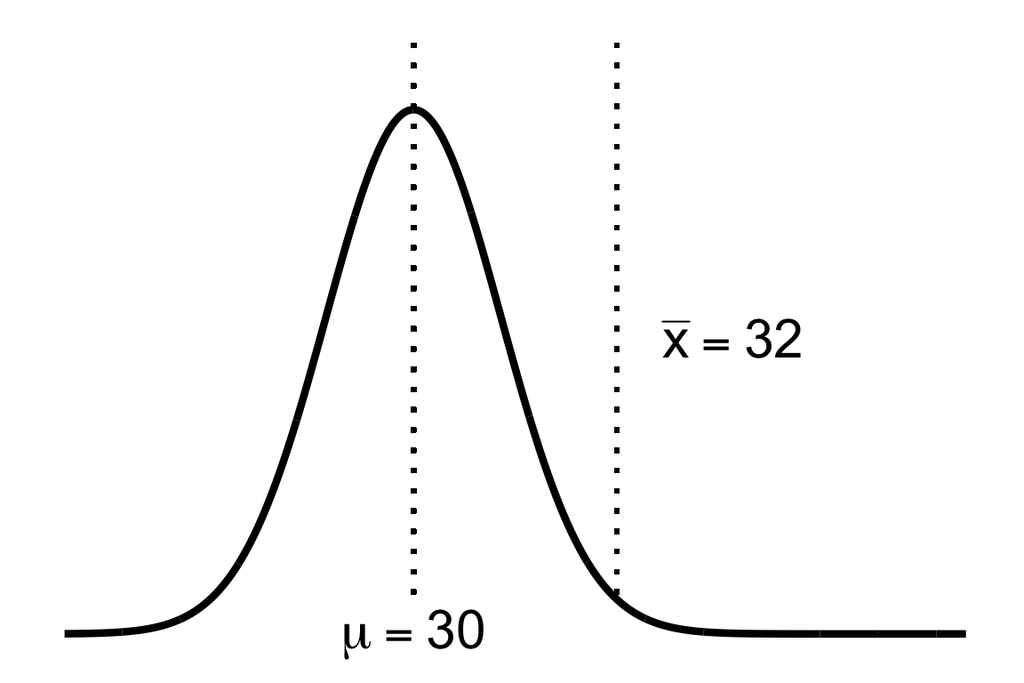

## Test Strategy

\(\bar{x} > C\)

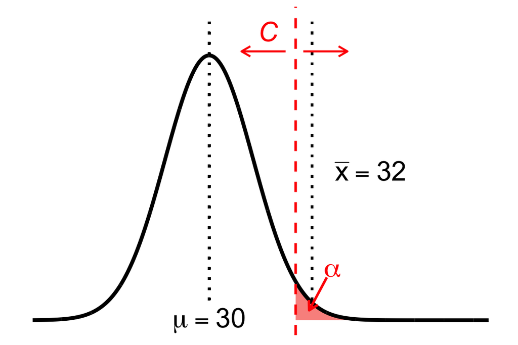

## Example continued

- Suppose we choose \(\alpha = 0.05\):

  \(Z_{1-\alpha} = Z_{0.95} = 1.645\)
- Hence, \(C = 30 + 1.645 = 31.645\)
- Since our mean \(\bar{x} = 32\) we reject the null hypothesis

```r
qnorm(.95)
```

```
## [1] 1.644854
```

## Discussion

- In general we don't convert \(C\) back to the original scale
- We would just reject because the Z-score; which is how manystandard errors the sample mean is above the hypothesized mean\[ \frac{32 - 30}{10 / \sqrt{100}} = 2 \]is greater than \(1.645\)
- Or, whenever \(\sqrt{n} (\bar X - \mu_0) / s > Z_{1-\alpha}\)

## General rules

- The \(Z\) test for \(H_0:\mu = \mu_0\) versus
  - \(H_1: \mu < \mu_0\)
  - \(H_2: \mu \neq \mu_0\)
  - \(H_3: \mu > \mu_0\)
- Test statistic \(TS = \frac{\bar{X} - \mu_0}{S / \sqrt{n}}\)
- Reject the null hypothesis when
  - \(TS \leq -Z_{1 - \alpha}\)
  - \(|TS| \geq Z_{1 - \alpha / 2}\)
  - \(TS \geq Z_{1 - \alpha}\)

## Hypothesis testing

- The alternative hypotheses are typically of the form \(<\), \(>\) or \(\neq\)
- Note that there are four possible outcomes of our statistical decision process

| Truth | Decide | Result |
| --- | --- | --- |
| \(H_0\) | \(H_0\) | Correctly accept null |
| \(H_0\) | \(H_a\) | Type I error |
| \(H_a\) | \(H_a\) | Correctly reject null |
| \(H_a\) | \(H_0\) | Type II error |

## Notes

- We have fixed \(\alpha\) to be low, so if we reject \(H_0\) (eitherour model is wrong) or there is a low probability that we have madean error
- We have not fixed the probability of a type II error, \(\beta\);therefore we tend to say "Fail to reject \(H_0\)" rather thanaccepting \(H_0\)
- Statistical significance is no the same as scientificsignificance

## Small Sample Sizes

- The \(Z\) test requires the assumptions of the CLT and for \(n\) to be large enoughfor it to apply
- If \(n\) is small, then a Gossett's \(T\) test is performed exactly in the same way,with the normal quantiles replaced by the appropriate Student's \(T\) quantiles and\(n-1\) df

## Normal vs. T Distribution

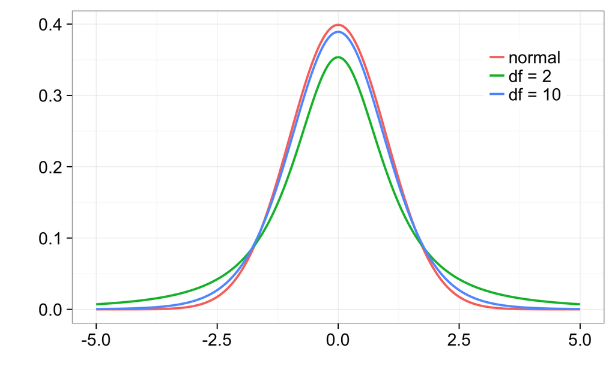

## Example Reconsidered (Small Sample Size)

- Consider our example again. Suppose that \(n= 16\) (rather than\(100\)). Then consider that\[ .05 = P\left(\frac{\bar X - 30}{s / \sqrt{16}} \geq t_{1-\alpha, 15} ~|~ \mu = 30 \right) \]
- So that our test statistic is now \(\sqrt{16}(32 - 30) / 10 = 0.8\), while the critical value is \(t_{1-\alpha, 15} = 1.75\).
- We now fail to reject.

```r
qt(.95, df=15)
```

```
## [1] 1.75305
```

## Two sided tests

- Suppose that we would reject the null hypothesis if in fact themean was too large or too small
- That is, we want to test the alternative \(H_a : \mu \neq 30\)(doesn't make a lot of sense in our setting)
- Then note\[ \alpha = P\left(\left. \left|\frac{\bar X - 30}{s /\sqrt{16}}\right| > t_{1-\alpha/2,15} ~\right|~ \mu = 30\right) \]
- That is we will reject if the test statistic, \(0.8\), is eithertoo large or too small, but the critical value is calculated using\(\alpha / 2\)
- In our example the critical value is \(2.13\), so we fail to reject.

```r
qt((1-0.05/2), 15)
```

```
## [1] 2.13145
```

## t-tests in R

## Example 1: Father vs. Son Heights

```r
library(UsingR); data(father.son)
head(father.son, 5)
```

```
##    fheight  sheight
## 1 65.04851 59.77827
## 2 63.25094 63.21404
## 3 64.95532 63.34242
## 4 65.75250 62.79238
## 5 61.13723 64.28113
```

## Example 1 cont'd

Compare means of two paired variables with **one sample t-test**.

\(H_0\): Difference between father and son heights \(= 0\).  
\(H_a\): Diffenence in means \(\neq 0\).

```r
t.test(father.son$fheight - father.son$sheight)
```

```
##
##  One Sample t-test
##
## data:  father.son$fheight - father.son$sheight
## t = -11.789, df = 1077, p-value < 2.2e-16
## alternative hypothesis: true mean is not equal to 0
## 95 percent confidence interval:
##  -1.1629160 -0.8310296
## sample estimates:
##  mean of x
## -0.9969728
```

## Example 1 cont'd

Same test with **two sample paired t-test**

```r
library(tidyr); fs <- gather(father.son, person, height)
head(fs, 3)
```

```
##    person   height
## 1 fheight 65.04851
## 2 fheight 63.25094
## 3 fheight 64.95532
```

```r
t.test(height ~ person, data = fs, paired = TRUE, alternative = "two.sided")
```

```
##
##  Paired t-test
##
## data:  height by person
## t = -11.789, df = 1077, p-value < 2.2e-16
## alternative hypothesis: true difference in means is not equal to 0
## 95 percent confidence interval:
##  -1.1629160 -0.8310296
## sample estimates:
## mean of the differences
##              -0.9969728
```

## Example 2

**Two sample t test** (not paired)

```r
head(iris, 3)
```

```
##   Sepal.Length Sepal.Width Petal.Length Petal.Width Species
## 1          5.1         3.5          1.4         0.2  setosa
## 2          4.9         3.0          1.4         0.2  setosa
## 3          4.7         3.2          1.3         0.2  setosa
```

```r
sv <- iris[iris$Species %in% c("setosa", "versicolor"),]
t.test(Sepal.Length ~ Species, data = sv, conf.level = 0.99)
```

```
##
##  Welch Two Sample t-test
##
## data:  Sepal.Length by Species
## t = -10.521, df = 86.538, p-value < 2.2e-16
## alternative hypothesis: true difference in means is not equal to 0
## 99 percent confidence interval:
##  -1.1628178 -0.6971822
## sample estimates:
##     mean in group setosa mean in group versicolor
##                    5.006                    5.936
```

## Example 3

**ANOVA**

\(H_0: \mu_{setosa} = \mu_{versicolor} = \mu_{virginia}\)  
\(H_a:\) not all \(\mu_i\) (\(i =\) setosa, versicolor, virginia) are equal

```r
lm <- lm(Sepal.Length ~ Species, data = iris)
anova(lm)
```

```
## Analysis of Variance Table
##
## Response: Sepal.Length
##            Df Sum Sq Mean Sq F value    Pr(>F)
## Species     2 63.212  31.606  119.26 < 2.2e-16 ***
## Residuals 147 38.956   0.265
## ---
## Signif. codes:  0 '***' 0.001 '**' 0.01 '*' 0.05 '.' 0.1 ' ' 1
```

## P-values

- The P-value is the probability under the null hypothesis of obtaining evidence as extreme or more extreme than would be observed by chance alone
- If the P-value is small, then either \(H_0\) is true and we have observed a rare event or \(H_0\) is false
- In our example the \(T\) statistic was \(0.8\).
- What's the probability of getting a \(T\) statistic as large as \(0.8\)?

```r
pt(0.8, 15, lower.tail = FALSE)
```

```
## [1] 0.218099
```

- Therefore, the probability of seeing evidence as extreme or more extreme than that actually obtained under \(H_0\) is 0.218099

## Notes

- By reporting a P-value the reader can perform the hypothesistest at whatever \(\alpha\) level he or she chooses
- If the P-value is less than \(\alpha\) you reject the null hypothesis
- For two sided hypothesis test, double the smaller of the two onesided hypothesis test P-values

## Power of Hypothesis Test

## Power

- Power is the probability of rejecting the null hypothesis when it is false
- Ergo, power (as it's name would suggest) is a good thing; you want more power
- A type II error (a bad thing, as its name would suggest) is failing to reject the null hypothesis when it's false; the probability of a type II error is usually called \(\beta\)
- Note Power \(= 1 - \beta\)

## Power

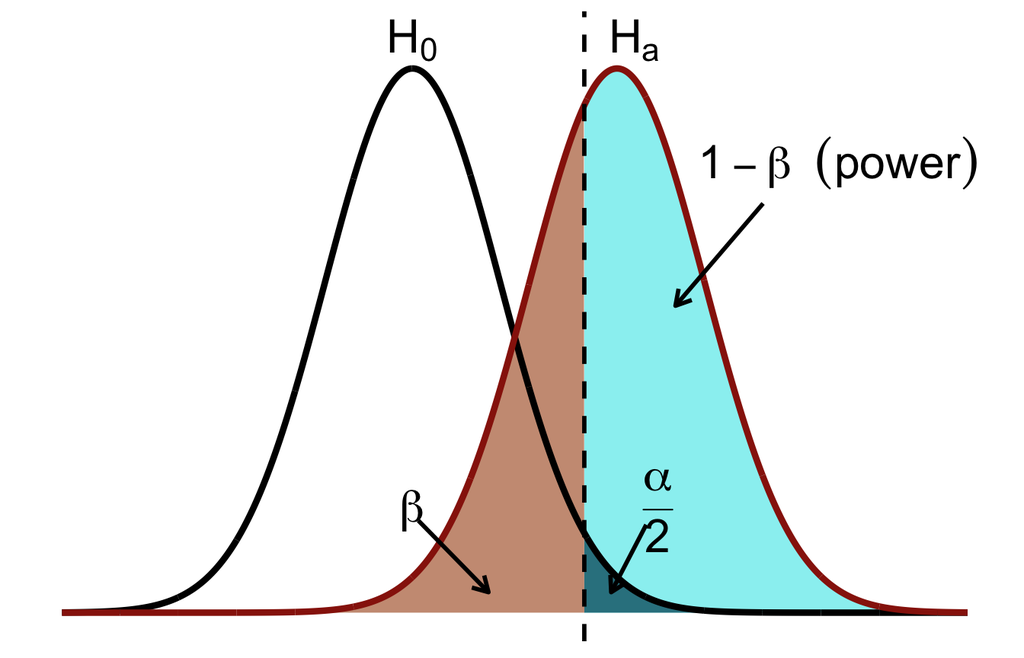

## Notes

- Consider our previous example involving CSI
- \(H_0: \mu = 30\) versus \(H_a: \mu > 30\)
- Then power is\[P\left(\frac{\bar X - 30}{s /\sqrt{n}} > t_{1-\alpha,n-1} ~|~ \mu = \mu_a \right)\]
- Note that this is a function that depends on the specific value of \(\mu_a\)!
- Notice as \(\mu_a\) approaches \(30\) the power approaches \(\alpha\)

## Calculating Power for Gaussian Data

Assume that \(n\) is large and that we know \(\sigma\)\[ \begin{align} 1 -\beta & = P\left(\frac{\bar X - 30}{\sigma /\sqrt{n}} > z_{1-\alpha} ~|~ \mu = \mu_a \right)\\ & = P\left(\frac{\bar X - \mu_a + \mu_a - 30}{\sigma /\sqrt{n}} > z_{1-\alpha} ~|~ \mu = \mu_a \right)\\ \\ & = P\left(\frac{\bar X - \mu_a}{\sigma /\sqrt{n}} > z_{1-\alpha} - \frac{\mu_a - 30}{\sigma /\sqrt{n}} ~|~ \mu = \mu_a \right)\\ \\ & = P\left(Z > z_{1-\alpha} - \frac{\mu_a - 30}{\sigma /\sqrt{n}} ~|~ \mu = \mu_a \right)\\ \\ \end{align} \]

## Power for CSI Example

\[ \begin{align} 1 -\beta & = P\left(Z > z_{1-\alpha} - \frac{\mu_a - 30}{\sigma /\sqrt{n}}\right)\\ & = P\left(Z > z_{0.95} - \frac{32 - 30}{10 /\sqrt{100}}\right)\\ & = P\left(Z > 1.645 - 2\right)\\ & = P(Z > -0.355)\\ & = .639 \end{align} \]

```r
z  <- qnorm(0.95)
pnorm(z - 2, lower.tail = FALSE)
```

```
## [1] 0.63876
```

## Calculating T-Test Power with R

```r
power.t.test(power = NULL, n = 100, delta = 2, sd = 10,
             type = "one.sample",  alt = "one.sided")
```

```
##
##      One-sample t test power calculation
##
##               n = 100
##           delta = 2
##              sd = 10
##       sig.level = 0.05
##           power = 0.6336178
##     alternative = one.sided
```

## Finding Minimum Sample Size

Suppose we want a power of 80%, what is the minimum sample size?

```r
power.t.test(power = 0.8, n = NULL, delta = 2, sd = 10,
             type = "one.sample",  alt = "one.sided")$n
```

```
## [1] 155.9257
```

power.t.test automatically solves the equation for the parameter set to NULL.

## Acknowledgements

This class and many slides were inspired by:

**Brian Caffo, Jeff Leek, and Roger Peng**  
Department of Biostatistics  
Johns Hopkins Bloomberg School of Public Health

and the

[Coursera Data Science Specialization Program](https://www.coursera.org/specialization/jhudatascience/1?utm_medium=courseDescripTop)